# OKEX BTC Hourly Data Analysis

Yuwei Cheng

Created on 2021-05-24. Updated on 2021-05-30.

```r
# Load libraries
suppressMessages(library(stringr))
suppressMessages(library(dplyr))
suppressMessages(library(lubridate))
suppressMessages(library(ggplot2))
suppressMessages(library(tidyr))
suppressMessages(library(scales))
suppressMessages(library(ggpubr))
suppressMessages(library(fastDummies))
#library(forecast)
#library(tseries)
suppressMessages(library(zoo))
```

```r
# Split different types of contract
splitCon = function(x,name)
{
  x %>% subset(contract_type %in% c(name)) %>%
    select(close, trade_time, symbol, vol, date)
}

makedf = function(x,y)
{
  common_time = intersect(x$trade_time, y$trade_time)
  x = x %>% subset(trade_time %in% common_time)
  y = y %>% subset(trade_time %in% common_time)

  df = merge(x,y,by = "trade_time") %>%
    mutate(diff = close.x - close.y) %>%
    mutate(return = (close.x - close.y)/close.y)

  df = df[!duplicated(df),]

  return(df)
}

returnDist = function(x, t1, t2)
{
  a = quantile(x$return[x$trade_time<t1],
                        c(0, 0.025, 0.25, 0.5, 0.75, 0.975, 1))
  b = quantile(x$return[x$trade_time>t1 & x$trade_time<t2],
                        c(0, 0.025, 0.25, 0.5, 0.75, 0.975, 1))
  c = quantile(x$return[x$trade_time>t2],
                        c(0, 0.025, 0.25, 0.5, 0.75, 0.975, 1))
  # print(paste0("Premium distribution prior ", t1))
  # print(signif(a, 3))
  # print(paste0("Premium distribution between ", t1, " and ", t2))
  # print(signif(b, 3))
  # print(paste0("Premium distribution after ", t2))
  # print(signif(c, 3))

  return(rbind(a,b,c))
}

returnPlot = function(x,t1,t2)
{
  par(mfrow = c(1,3), mar = c(3,3,1,1))
  hist(x$return[x$trade_time<t1], xlab = "", ylab = "return", main = NULL)
  hist(x$return[x$trade_time>t1 & x$trade_time<t2],
        xlab = "", ylab = "return",  main = NULL)
  hist(x$return[x$trade_time>t2],  xlab = "", ylab = "return",  main = NULL)
  par(mfrow = c(1,1))
}

#' @name coumputeIRR
#' @param r percentage premium
#' @param contract type of contract，当周，次周，当季，次季
#' @note
#'      [1]compute the lower bound of the annual rate of return
#'      [2]do not include service charge
#'      [3]IRR was computed by assuming that we close position at the delivery
#'         time and prices converge to 0
#-------------------------------------------------------------------------------
computeIRR = function(r, contract)
{
  if(contract == "Current Week")
  {
    return((1+r)^floor(365/7)-1)
  }else if(contract == "Next Week")
  {
    return((1+r)^floor(365/14)-1)
  }else if(contract == "Current Season")
  {
    return((1+r)^floor(365/93)-1)
  }else
  {
    return((1+r)^floor(365/186)-1)
  }
}

descriptiveAnalysis = function(x, t1, t2, threshold1, threshold2, contract)
{
  r = returnDist(x, t1, t2)

  p1 = x %>% ggplot() +
    geom_line(aes(x = trade_time, y = return),
              color = "steelblue") + theme_bw() +
    geom_vline(xintercept = c(t1, t2),
               linetype = "dotted",color = "red")+
    scale_x_datetime(breaks = date_breaks("1 month"),
                     date_labels = "%b-%d"
                     # minor_breaks = date_breaks("1 day")
                     )+
    labs(x = NULL, title = NULL, y = "premium (%)")

  t1 = x %>% subset(return < threshold1) %>%
    select(trade_time, close.x, vol.x, close.y, vol.y, diff, return) %>%
    rename("futures close price" = "close.x") %>%
    rename("swap close price" = "close.y") %>%
    rename("futures vol" = "vol.x") %>%
    rename("swap vol" = "vol.y")

  t2 = x %>% subset(return < threshold2) %>%
    select(trade_time, close.x, vol.x, close.y, vol.y, diff, return) %>%
    rename("futures close price" = "close.x") %>%
    rename("swap close price" = "close.y") %>%
    rename("futures vol" = "vol.x") %>%
    rename("swap vol" = "vol.y")

  irr = apply(r[,4:7], 1, function(y){computeIRR(y, contract)})
  colnames(irr) = c("2020年11月前",
                    "2020年11月-2021年4月15号",
                    "2021年4月15号之后")
 return(list(
   r = r,
   p1 = p1,
   t1 = t1,
   t2 = t2,
   irr = irr
 ))
}

volumePlot = function(y)
{
 p = y %>% group_by(date) %>%
   summarize(sum = sum(vol)) %>%
   ggplot() + geom_line(aes(x = date, y = sum), color = "steelblue") +
   theme_bw() +
   scale_y_log10(
     breaks = trans_breaks("log10", function(x) 10^x),
     labels = trans_format("log10", math_format(10^.x))) +
   geom_vline(xintercept = y$date[weekdays(y$date) == "星期五"],
              color = "red", linetype = "dotted") +
   # geom_vline(xintercept = y$date[weekdays(y$date) == "星期一"],
   #            color = "green", linetype = "dotted") +
   scale_x_date(date_breaks = "1 month", date_label = "%b-%d") +
   labs(x = NULL, y = "date volume")
 return(p)
}

volatilityPlot = function(y)
{
   p = y %>% group_by(date) %>%
   summarize(volatility = sd(close), u = mean(close)) %>%
   ggplot() + geom_line(aes(x = date, y = volatility/u), color = "steelblue") +
   theme_bw() +
   # scale_y_log10(
   #   breaks = trans_breaks("log10", function(x) 10^x),
   #   labels = trans_format("log10", math_format(10^.x)),
   #   limits = c(10^3, 10^8)) +
   # geom_vline(xintercept = y$date[weekdays(y$date) == "星期五"],
   #            color = "red", linetype = "dotted") +
   # geom_vline(xintercept = y$date[weekdays(y$date) == "星期一"],
   #            color = "green", linetype = "dotted") +
   scale_x_date(date_breaks = "1 month", date_label = "%b-%d") +
   labs(x = NULL, y = "date volatility")
 return(p)
}

volumeAnalysis = function(x)
{
  x$weekday = weekdays(x$date)
  y = dummy_cols(x$weekday)[-c(1,5)]
  colnames(y) = c("Mon","Tue","Wed","Thu","Sat","Sun")
  x = cbind(x, y)
  model = lm(vol ~ Mon + Tue + Wed + Thu + Sat + Sun, data = x)
  return(model)
}
```

```r
data = read.csv("C:/Users/yuwei/guyi Dropbox/Yuwei Cheng/TG RESEARCH's shared workspace/tradeAnalysis/data/BTC/btc_usdt_60min_all.csv")

# Exchange platform: OKEX
# TS_code: BTC_USDT
# Freq: on hour, 60 minutes
# Is_contract: Yes

data = data %>%
  select(-X, - exchange, - ts_code, -freq, -is_contract) %>%
  mutate(trade_time = ymd_hm(trade_time))

data$contract_type =
  do.call(rbind,
          str_split(data$symbol, "-", n = Inf, simplify = FALSE))[,3]

# Label contract type
data = data %>%
  mutate(contract_type =
           ifelse(contract_type != "SWAP",
                  contract_type, "180101")) %>%
  mutate(type = ymd(contract_type)) %>%
  mutate(date = as.Date(trade_time)) %>%
  mutate(difference = type - date) %>%
  mutate(contract_type  =
           ifelse(difference <0, "SWAP",
                  ifelse(difference >= 90, "4 Next Season",
                         ifelse(difference >=14, "3 Current Season",
                                ifelse(difference >= 7, "2 Next Week",
                                       "1 Current Week")))))%>%
  select(-difference, -date, -type)

data$date = as.Date(data$trade_time)
```

```r
current_week  = splitCon(data, "1 Current Week")
next_week = splitCon(data, "2 Next Week")
current_season = splitCon(data, "3 Current Season")
next_season = splitCon(data, "4 Next Season")
swap = splitCon(data, "SWAP")


df1 = makedf(current_week, swap)
df2 = makedf(next_week, swap)
df3 = makedf(current_season, swap)
df4 = makedf(next_season, swap)
```

# 1 当周合约和永续合约

## 1.1 溢价分析

$premium (\%) = \frac{P_{futures} - P_{swap}}{P_{swap}}$

2020年11月之前，溢价百分比的中位数在千一左右，Q3在千二左右，最高溢价百分比在千四。 2020年11月之后到2021年4月中之前，溢价百分比的中位数在千三左右，Q3在千四左右，最高溢价百分比百一。 2021年4月中之后，溢价百分比的中位数在千一左右，Q3在千三左右，最高溢价百分比千九。

正套的机会2021年4月中以后还是存在的，因为Q3的差别不是很大。

需要注意的是，反套的机会集中出现在2020年年末和2021年2月之间。当周的价格比永续的 价格最高低了三个百分点。这个机会出现在2021年2月23号下午两点。永续合约的交易量极低 只有1830。当然这个也有可能是错误数据。

反套溢价百分比小于千三的机会总共就只出现了12次

## 1.2 年化收益率

中基的年化收益在6%，Q3的年化收益在18%

## 1.3 成交量分析

```r
result1 = descriptiveAnalysis(df1,
                              df1$trade_time[820],
                              df1$trade_time[4046],
                              -0.01,
                              -0.003,
                              "Current Week")
result1$t1
```

```
##               trade_time futures close price futures vol swap close price
## 1589 2020-12-18 01:00:00             22700.8        8662          22993.4
## 1818 2020-12-29 10:00:00             26440.0           0          26744.5
## 1881 2021-01-01 01:00:00             29138.7       11027          29435.0
## 2200 2021-01-10 19:00:00             37666.0       75014          38310.4
## 2204 2021-01-10 20:00:00             37902.7      316285          38335.3
## 3192 2021-01-22 01:00:00             29230.1       36670          30046.5
## 5876 2021-02-23 14:00:00             47077.9      128974          48743.6
##      swap vol    diff      return
## 1589   251385  -292.6 -0.01272539
## 1818   104095  -304.5 -0.01138552
## 1881   289786  -296.3 -0.01006625
## 2200    10085  -644.4 -0.01682050
## 2204      239  -432.6 -0.01128464
## 3192   557375  -816.4 -0.02717122
## 5876     1830 -1665.7 -0.03417269
```

```r
result1$t2
```

```
##               trade_time futures close price futures vol swap close price
## 321  2020-10-01 18:00:00             10512.3        7480          10585.7
## 1589 2020-12-18 01:00:00             22700.8        8662          22993.4
## 1816 2020-12-29 08:00:00             26440.0           0          26662.4
## 1817 2020-12-29 09:00:00             26440.0           0          26589.8
## 1818 2020-12-29 10:00:00             26440.0           0          26744.5
## 1881 2021-01-01 01:00:00             29138.7       11027          29435.0
## 2200 2021-01-10 19:00:00             37666.0       75014          38310.4
## 2204 2021-01-10 20:00:00             37902.7      316285          38335.3
## 3192 2021-01-22 01:00:00             29230.1       36670          30046.5
## 4944 2021-02-12 01:00:00             48229.5        9314          48525.6
## 5876 2021-02-23 14:00:00             47077.9      128974          48743.6
## 7459 2021-03-19 01:00:00             57019.0       14533          57388.0
##      swap vol    diff       return
## 321    328925   -73.4 -0.006933883
## 1589   251385  -292.6 -0.012725391
## 1816   126933  -222.4 -0.008341335
## 1817    48824  -149.8 -0.005633739
## 1818   104095  -304.5 -0.011385519
## 1881   289786  -296.3 -0.010066248
## 2200    10085  -644.4 -0.016820498
## 2204      239  -432.6 -0.011284638
## 3192   557375  -816.4 -0.027171218
## 4944   112261  -296.1 -0.006101934
## 5876     1830 -1665.7 -0.034172691
## 7459    92458  -369.0 -0.006429916
```

```r
signif(result1$irr, 2)
```

```
##       2020年11月前 2020年11月-2021年4月15号 2021年4月15号之后
## 50%          0.059                     0.14             0.061
## 75%          0.100                     0.25             0.180
## 97.5%        0.220                     0.66             0.470
## 100%         0.280                     1.20             0.580
```

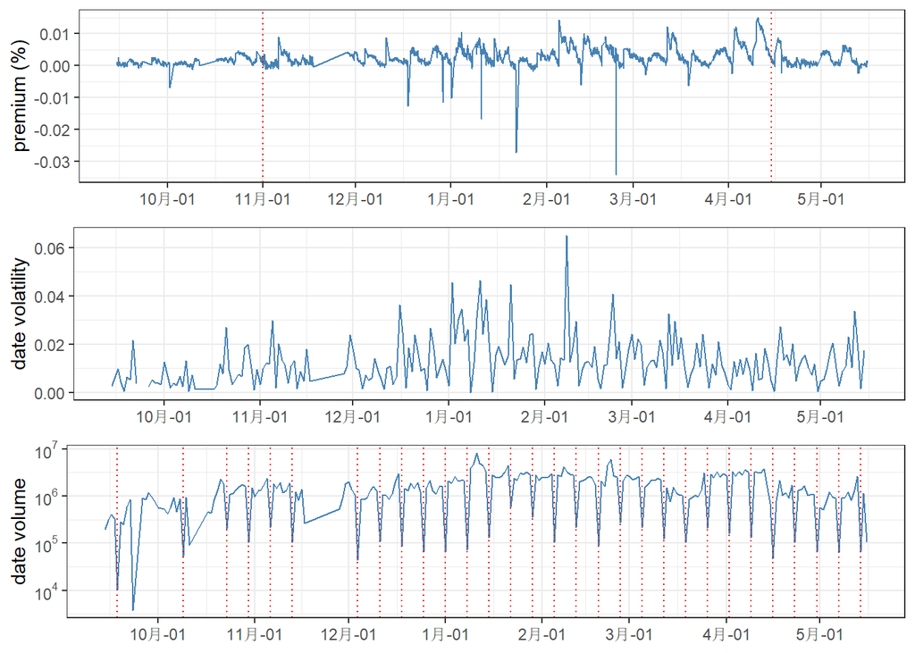

```r
p1 = result1$p1
p2 = volumePlot(current_week)
p3 = volatilityPlot(current_week)

ggarrange(p1,p3,p2,nrow = 3)
```

```r
summary(volumeAnalysis(current_week))
```

```
##
## Call:
## lm(formula = vol ~ Mon + Tue + Wed + Thu + Sat + Sun, data = x)
##
## Residuals:
##    Min     1Q Median     3Q    Max
## -64865 -25456 -12715  11799 542258
##
## Coefficients:
##             Estimate Std. Error t value Pr(>|t|)
## (Intercept)  52159.1     4900.7  10.643  < 2e-16 ***
## Mon          15766.3     5093.9   3.095  0.00198 **
## Tue          11101.1     5100.6   2.176  0.02956 *
## Wed          10536.4     5094.7   2.068  0.03867 *
## Thu           1111.7     5087.8   0.218  0.82705
## Sat          13175.7     5101.9   2.583  0.00983 **
## Sun            218.6     5093.9   0.043  0.96578
## ---
## Signif. codes:  0 '***' 0.001 '**' 0.01 '*' 0.05 '.' 0.1 ' ' 1
##
## Residual standard error: 43830 on 5998 degrees of freedom
## Multiple R-squared:  0.01824,    Adjusted R-squared:  0.01726
## F-statistic: 18.58 on 6 and 5998 DF,  p-value: < 2.2e-16
```

## 1.4 次周合约和永续合约

2020年11月之前，溢价百分比的中位数在千二左右，Q3在千三左右，最高溢价百分比在千六。 2020年11月之后到2021年4月中之前，溢价百分比的中位数在千七左右，Q3在百一左右，最高溢价百分比百三。 2021年4月中之后，溢价百分比的中位数在千四左右，Q3在千六左右，最高溢价百分比百一点五。

反套溢价百分比小于前三的机会总共就只出现了6次

## 1.5 年化收益率

中基的年化收益在11%，Q3的年化收益在17%

## 1.6 成交量分析

周五往往是每周成交量最多的一天。每天的成交量大多在在30万到三百万之间。从今年一月 份开始daily price volatility很大，差不多是每日均价的3%

```r
result2 = descriptiveAnalysis(df2,
                              df1$trade_time[820],
                              df1$trade_time[4046],
                              -0.01,
                              -0.003,
                              "Next Week")
result2$r[,4:7]
```

```
##           50%         75%       97.5%        100%
## a 0.002097397 0.003389161 0.005536048 0.006644084
## b 0.007038821 0.010174923 0.019081732 0.026080074
## c 0.003982809 0.005923439 0.009869917 0.014058120
```

```r
result2$t1
```

```
##               trade_time futures close price futures vol swap close price
## 2648 2021-01-10 19:00:00             37799.9       33649          38310.4
## 6852 2021-02-23 14:00:00             47606.6       70145          48743.6
##      swap vol    diff      return
## 2648    10085  -510.5 -0.01332536
## 6852     1830 -1137.0 -0.02332614
```

```r
result2$t2
```

```
##                trade_time futures close price futures vol swap close price
## 2648  2021-01-10 19:00:00             37799.9       33649          38310.4
## 2652  2021-01-10 20:00:00             38181.2      153018          38335.3
## 6852  2021-02-23 14:00:00             47606.6       70145          48743.6
## 9421  2021-04-18 03:00:00             54256.2      245966          54681.9
## 9422  2021-04-18 04:00:00             54584.1       95752          54863.8
## 10026 2021-05-13 08:00:00             49904.9       37115          50074.6
##       swap vol    diff       return
## 2648     10085  -510.5 -0.013325363
## 2652       239  -154.1 -0.004019794
## 6852      1830 -1137.0 -0.023326139
## 9421   1200877  -425.7 -0.007785026
## 9422    532000  -279.7 -0.005098079
## 10026   225729  -169.7 -0.003388944
```

```r
signif(result2$irr, 2)
```

```
##       2020年11月前 2020年11月-2021年4月15号 2021年4月15号之后
## 50%          0.056                     0.20              0.11
## 75%          0.092                     0.30              0.17
## 97.5%        0.150                     0.63              0.29
## 100%         0.190                     0.95              0.44
```

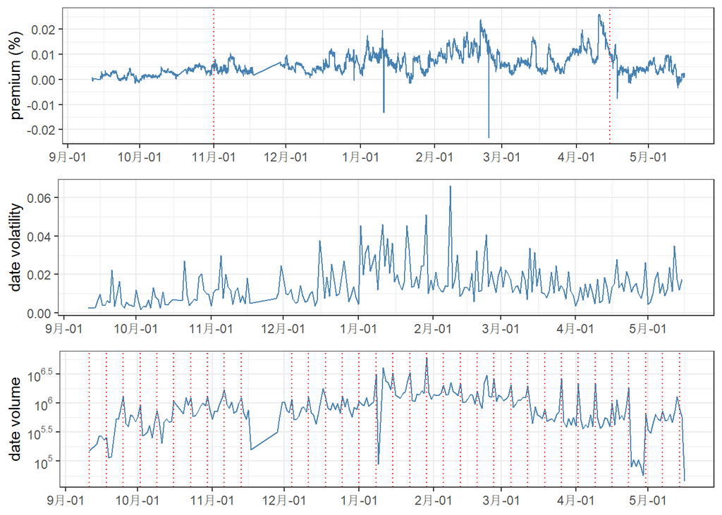

```r
p1 = result2$p1
p2 = volumePlot(next_week)
p3 = volatilityPlot(next_week)

ggarrange(p1,p3,p2,nrow = 3)
```

```r
summary(volumeAnalysis(next_week))
```

```
##
## Call:
## lm(formula = vol ~ Mon + Tue + Wed + Thu + Sat + Sun, data = x)
##
## Residuals:
##    Min     1Q Median     3Q    Max
## -55401 -11509  -4253   5170 443701
##
## Coefficients:
##             Estimate Std. Error t value Pr(>|t|)
## (Intercept)  55634.0      795.4   69.94   <2e-16 ***
## Mon         -24672.6     1133.9  -21.76   <2e-16 ***
## Tue         -26190.6     1130.2  -23.17   <2e-16 ***
## Wed         -26607.7     1130.2  -23.54   <2e-16 ***
## Thu         -32949.1     1131.3  -29.12   <2e-16 ***
## Sat         -25228.0     1130.2  -22.32   <2e-16 ***
## Sun         -33222.2     1137.1  -29.22   <2e-16 ***
## ---
## Signif. codes:  0 '***' 0.001 '**' 0.01 '*' 0.05 '.' 0.1 ' ' 1
##
## Residual standard error: 25490 on 7027 degrees of freedom
## Multiple R-squared:  0.1442, Adjusted R-squared:  0.1435
## F-statistic: 197.3 on 6 and 7027 DF,  p-value: < 2.2e-16
```

## 1.9 成交量分析

```r
result3 = descriptiveAnalysis(df3,
                              df1$trade_time[820],
                              df1$trade_time[4046],
                              -0.01,
                              -0.003,
                              "Current Season")

signif(result3$r[,4:7],2)
```

```
##     50%   75% 97.5%  100%
## a 0.015 0.018 0.023 0.025
## b 0.014 0.035 0.071 0.083
## c 0.034 0.039 0.065 0.071
```

```r
result3$t1
```

```
##               trade_time futures close price futures vol swap close price
## 8800 2021-02-23 14:00:00             48067.5      304300          48743.6
##      swap vol   diff      return
## 8800     1830 -676.1 -0.01387054
```

```r
result3$t2
```

```
##                trade_time futures close price futures vol swap close price
## 2385  2020-12-18 07:00:00             22960.0       59315          23065.0
## 2867  2021-01-08 07:00:00             38738.3       56133          38867.3
## 3724  2021-01-15 07:00:00             38258.6       58197          38516.2
## 6482  2021-02-05 07:00:00             37562.2       45637          37704.9
## 7402  2021-02-12 07:00:00             47216.0       35172          47402.2
## 8800  2021-02-23 14:00:00             48067.5      304300          48743.6
## 11076 2021-03-26 07:00:00             53010.9      166445          53540.3
## 11496 2021-04-09 07:00:00             57878.5      123560          58074.5
## 11726 2021-04-16 07:00:00             61192.8       48770          61465.5
## 12646 2021-05-14 07:00:00             49794.5       50102          50059.2
##       swap vol   diff       return
## 2385    152750 -105.0 -0.004552352
## 2867    168424 -129.0 -0.003318985
## 3724    169862 -257.6 -0.006688095
## 6482    112012 -142.7 -0.003784654
## 7402     94921 -186.2 -0.003928088
## 8800      1830 -676.1 -0.013870539
## 11076   223924 -529.4 -0.009887879
## 11496    63990 -196.0 -0.003374975
## 11726   124232 -272.7 -0.004436635
## 12646   200130 -264.7 -0.005287739
```

```r
signif(result3$irr, 2)
```

```
##       2020年11月前 2020年11月-2021年4月15号 2021年4月15号之后
## 50%          0.046                    0.043              0.11
## 75%          0.056                    0.110              0.12
## 97.5%        0.070                    0.230              0.21
## 100%         0.076                    0.270              0.23
```

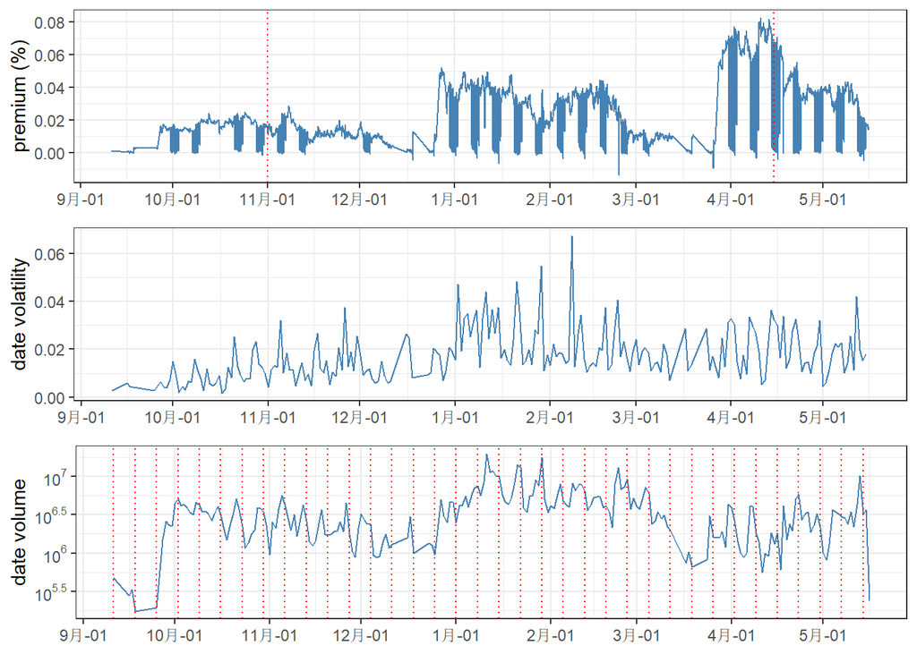

```r
p1 = result3$p1
p2 = volumePlot(current_season)
p3 = volatilityPlot(current_season)

ggarrange(p1,p3,p2,nrow = 3)
```

```r
summary(volumeAnalysis(current_season))
```

```
##
## Call:
## lm(formula = vol ~ Mon + Tue + Wed + Thu + Sat + Sun, data = x)
##
## Residuals:
##     Min      1Q  Median      3Q     Max
## -113794  -48357  -22876   22912 1185854
##
## Coefficients:
##             Estimate Std. Error t value Pr(>|t|)
## (Intercept)    77170       1981  38.959  < 2e-16 ***
## Mon            44223       3436  12.869  < 2e-16 ***
## Tue            16984       2992   5.676 1.42e-08 ***
## Wed            36625       3436  10.658  < 2e-16 ***
## Thu            11573       3500   3.307 0.000947 ***
## Sat            11747       2814   4.174 3.02e-05 ***
## Sun            11979       3436   3.486 0.000493 ***
## ---
## Signif. codes:  0 '***' 0.001 '**' 0.01 '*' 0.05 '.' 0.1 ' ' 1
##
## Residual standard error: 84800 on 8656 degrees of freedom
## Multiple R-squared:  0.0258, Adjusted R-squared:  0.02513
## F-statistic: 38.21 on 6 and 8656 DF,  p-value: < 2.2e-16
```

```r
result4 = descriptiveAnalysis(df4,
                              df1$trade_time[820],
                              df1$trade_time[4046],
                              -0.00,
                              -0.001,
                              "Next Season")
signif(result4$r[,4:7])
```

```
##         50%       75%     97.5%      100%
## a 0.0245318 0.0310722 0.0412392 0.0457336
## b 0.0595885 0.0749588 0.1232300 0.1493450
## c 0.0899717 0.0939165 0.1272700 0.1339700
```

```r
result4$t1
```

```
##                trade_time futures close price futures vol swap close price
## 3328  2020-12-09 20:00:00             18333.4       50321          18338.3
## 3351  2020-12-10 07:00:00             18339.4       35988          18340.7
## 3357  2020-12-10 10:00:00             18147.8       65490          18157.0
## 3358  2020-12-10 11:00:00             18190.9       53457          18198.0
## 3388  2020-12-11 02:00:00             17802.0       70412          17808.2
## 3393  2020-12-11 04:00:00             17957.4       53354          17960.4
## 3394  2020-12-11 05:00:00             17892.7       61792          17900.0
## 3396  2020-12-11 06:00:00             17911.9       51983          17919.6
## 3399  2020-12-11 07:00:00             17766.0       93283          17813.3
## 10514 2021-03-11 15:00:00             56365.5       64312          56367.2
## 10602 2021-03-12 02:00:00             56952.3       32066          56963.4
## 10636 2021-03-12 06:00:00             57047.3       34145          57074.1
##       swap vol  diff        return
## 3328    100109  -4.9 -2.672003e-04
## 3351     54948  -1.3 -7.088061e-05
## 3357    198556  -9.2 -5.066916e-04
## 3358    142880  -7.1 -3.901528e-04
## 3388    207221  -6.2 -3.481542e-04
## 3393     88423  -3.0 -1.670341e-04
## 3394     87237  -7.3 -4.078212e-04
## 3396     81040  -7.7 -4.296971e-04
## 3399    205508 -47.3 -2.655319e-03
## 10514   289568  -1.7 -3.015938e-05
## 10602    93910 -11.1 -1.948620e-04
## 10636    98617 -26.8 -4.695650e-04
```

```r
result4$t2
```

```
##               trade_time futures close price futures vol swap close price
## 3399 2020-12-11 07:00:00               17766       93283          17813.3
##      swap vol  diff       return
## 3399   205508 -47.3 -0.002655319
```

```r
signif(result4$irr, 2)
```

```
##       2020年11月前 2020年11月-2021年4月15号 2021年4月15号之后
## 50%          0.025                    0.060             0.090
## 75%          0.031                    0.075             0.094
## 97.5%        0.041                    0.120             0.130
## 100%         0.046                    0.150             0.130
```

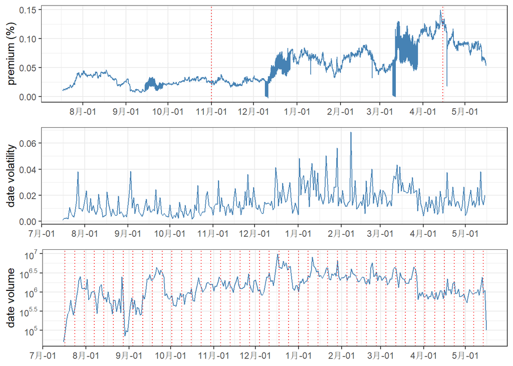

```r
p1 = result4$p1
p2 = volumePlot(next_season)
p3 = volatilityPlot(next_season)

ggarrange(p1,p3,p2,nrow = 3)
```

```r
summary(volumeAnalysis(next_season))
```

```
##
## Call:
## lm(formula = vol ~ Mon + Tue + Wed + Thu + Sat + Sun, data = x)
##
## Residuals:
##    Min     1Q Median     3Q    Max
## -60599 -25581 -12205   9165 918009
##
## Coefficients:
##             Estimate Std. Error t value Pr(>|t|)
## (Intercept)    57874       1322  43.777  < 2e-16 ***
## Mon             3572       1910   1.870 0.061480 .
## Tue             2877       1889   1.523 0.127766
## Wed              595       1904   0.313 0.754638
## Thu           -10494       1874  -5.599 2.21e-08 ***
## Sat             6272       1877   3.342 0.000834 ***
## Sun           -11949       1916  -6.238 4.62e-10 ***
## ---
## Signif. codes:  0 '***' 0.001 '**' 0.01 '*' 0.05 '.' 0.1 ' ' 1
##
## Residual standard error: 49920 on 9542 degrees of freedom
## Multiple R-squared:  0.01692,    Adjusted R-squared:  0.0163
## F-statistic: 27.36 on 6 and 9542 DF,  p-value: < 2.2e-16
```